# Práctica Análisis Multivariante

Sergio

24/1/2022

### Feature engineering

Vamos a emplear un dataset que contiene las respuestas a una encuesta muy amplia sobre gustos e intereses (películas, musicales, hobbies, fobias, hábitos de salud, etc.). Además de las respuestas a la encuesta también hay algunos datos de los encuestados como edad, sexo, número de hermanos,…

```r
data <- read.csv('./data/responses.csv')
```

```r
dim(data)
```

```
## [1] 1010  150
```

Las dimensiones del dataset hacen un poco inútil hacer str o summary. No obstante tenemos mucha información sobre lo que contiene:

- Todas las variables correspondientes a preguntas toman valores 1, 2, 3, 4 o 5
- Hay unas pocas variables demográficas como género o zurdo/diestro que contienen valores categóricos

Todas las variables vienen muy bien descritas en la descripción del dataset:

### https://www.kaggle.com/miroslavsabo/young-people-survey

El objetivo de esta práctica será analizar si las preferencias musicales, preferencias de peliculas, actitudes ante la vida, hobbies y fobias definen quienes somos (hombre/mujer, de pueblo/de ciudad, zurdo/diestro,…). En esta línea la principal hipótesis que vamos a intentar aceptar o rechazar es “Tus gustos, intereses, opiniones y fobias definen quién eres”.

Dado que el dataset tiene muchas variables (150) vamos a ver como están repartidas (ver link arriba) para quedarnos solo con algunas:

- Music preferences (19 items)
- Movie preferences (12 items)
- Hobbies & interests (32 items)
- Phobias (10 items)
- Health habits (3 items)
- Personality traits, views on life, & opinions (57 items)
- Spending habits (7 items)
- Demographics (10 items)

Vamos a descartar las variables relacionadas con hábitos de salud y las relacionadas con hábitos de consumo ya que son categóricas (las respuestas a la encuesta son del estilo “Fumo”, “Antes fumaba”, “Nunca he fumado”).

En cambio sí nos quedaremos con las variables relacionadas con

- Gustos musicales
- Gustos de películas
- Hobbies e interes
- Opiniones y visión de la vida
- Fobias

Todas estas variables toman valores desde 1 hasta 5. Siendo 5 muy interesado y 1 muy poco interesado. Además nos quedaremos también con las variables demográficas (sexo, mano buena, edad, etc. ya que serán las que usaremos para contrastar nuestras hipótesis).

```r
library(dplyr)
```

```r
music <- data[,1:19]
movies <- data[,20:31]
hobbies <- data[,32:63]
phobias <- data[,64:73]
opinions <- data[,77:107]
opinions <- cbind(opinions, data[,110:132])
demographics <- data[,141:150]
#quitamos algunas variables demográficas que no intervendrán en el contraste de nuestra hipótesis (usaremos el resto)
demographics <- select(demographics, -Height, -Weight, -Number.of.siblings)

data <- cbind(music, movies)
data <- cbind(data,hobbies)
data <- cbind(data, phobias)
data <- cbind(data, opinions)
data <- cbind(data, demographics)
str(data)
```

```
## 'data.frame':    1010 obs. of  134 variables:
##  $ Music                         : int  5 4 5 5 5 5 5 5 5 5 ...
##  $ Slow.songs.or.fast.songs      : int  3 4 5 3 3 3 5 3 3 3 ...
##  $ Dance                         : int  2 2 2 2 4 2 5 3 3 2 ...
##  $ Folk                          : int  1 1 2 1 3 3 3 2 1 5 ...
##  $ Country                       : int  2 1 3 1 2 2 1 1 1 2 ...
##  $ Classical.music               : int  2 1 4 1 4 3 2 2 2 2 ...
##  $ Musical                       : int  1 2 5 1 3 3 2 2 4 5 ...
##  $ Pop                           : int  5 3 3 2 5 2 5 4 3 3 ...
##  $ Rock                          : int  5 5 5 2 3 5 3 5 5 5 ...
##  $ Metal.or.Hardrock             : int  1 4 3 1 1 5 1 1 5 2 ...
##  $ Punk                          : int  1 4 4 4 2 3 1 2 1 3 ...
##  $ Hiphop..Rap                   : int  1 1 1 2 5 4 3 3 1 2 ...
##  $ Reggae..Ska                   : int  1 3 4 2 3 3 1 2 2 4 ...
##  $ Swing..Jazz                   : int  1 1 3 1 2 4 1 2 2 4 ...
```

[output cut: 86 more lines]

Convertimos Age en una variable binaria para la visualización (<=20 y >20)

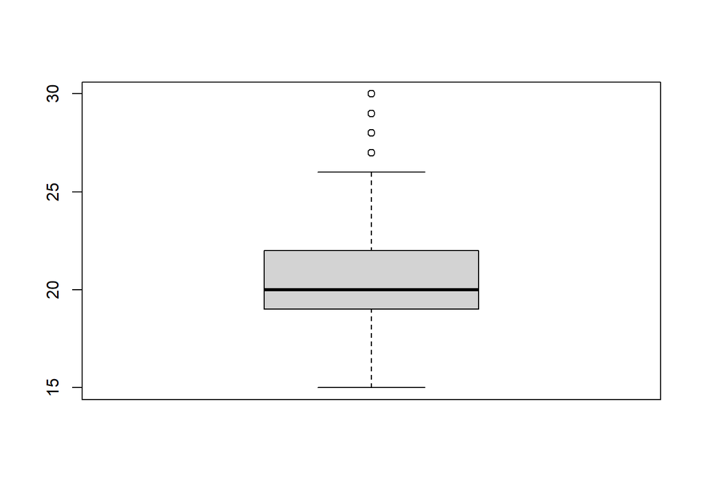

```r
boxplot(data$Age)
```

```r
data$Age <- data$Age <- ifelse(data$Age <= 20, "Less or equal 20", "More than 20")
```

Guardamos en un vector el nombre de las variables demográficas para quitarlas fácilmente para hacer el análisis (las variables demográficas las usaremos al final para contrastar nuestra hipótesis “Tus gustos, intereses y fobias definen quién eres”)

```r
demographics_column_names <- colnames(demographics)
demographics_column_names
```

```
## [1] "Age"                    "Gender"                 "Left...right.handed"
## [4] "Education"              "Only.child"             "Village...town"
## [7] "House...block.of.flats"
```

Hagamos ahora un análisis de missing values.

```r
sum(is.na(data))
```

```
## [1] 507
```

```r
apply(X = is.na(data), MARGIN = 2, FUN = sum)
```

```
##                          Music       Slow.songs.or.fast.songs
##                              3                              2
##                          Dance                           Folk
##                              4                              5
##                        Country                Classical.music
##                              5                              7
##                        Musical                            Pop
##                              2                              3
##                           Rock              Metal.or.Hardrock
##                              6                              3
##                           Punk                    Hiphop..Rap
##                              8                              4
##                    Reggae..Ska                    Swing..Jazz
##                              7                              6
##                    Rock.n.roll                    Alternative
##                              7                              7
##                         Latino                 Techno..Trance
##                              8                              7
##                          Opera                         Movies
##                              1                              6
##                         Horror                       Thriller
##                              2                              1
##                         Comedy                       Romantic
##                              3                              3
##                         Sci.fi                            War
##                              2                              2
##            Fantasy.Fairy.tales                       Animated
##                              3                              3
##                    Documentary                        Western
##                              8                              4
##                         Action                        History
##                              2                              2
##                     Psychology                       Politics
##                              5                              1
##                    Mathematics                        Physics
##                              3                              3
##                       Internet                             PC
##                              4                              6
##             Economy.Management                        Biology
##                              5                              6
```

[output cut: 79 more lines]

```
##                              4                              5
##               Small...big.dogs                    Personality
##                              4                              4
##         Finding.lost.valuables                     Getting.up
##                              4                              5
##           Interests.or.hobbies                Parents..advice
##                              3                              2
##        Questionnaires.or.polls                            Age
##                              4                              7
##                         Gender            Left...right.handed
##                              0                              0
##                      Education                     Only.child
##                              0                              0
##                 Village...town         House...block.of.flats
##                              0                              0
```

- 700 filas siguen siendo suficientes para nuestro estudio
- Los NAs posiblemente correspondan a gente que no quiso responder esa pregunta en la encuesta por lo que si tiene algo que ocultar es probable que mintiese en la respuesta a otras preguntas. Esto podría introducir datos falaces.

```r
data <- na.omit(data)
```

Algunos NA en las variables categóricas vienen en forma de caracteres vacios:

```r
data <- data[data$Gender != "",]
data <- data[data$Age != "",]
data <- data[data$Left...right.handed != "",]
data <- data[data$Village...town != "",]
data <- data[data$Only.child != "",]
dim(data)
```

```
## [1] 701 134
```

## Análisis descriptivo multivariante

Parece inviable analizar 140 variables a la vez por lo que iremos viendo algunas correlaciones y algunos insights que pueden ser interesantes seleccionando algunas de las variables.

Comencemos por ver que correlaciones existen entre los gustos musicales:

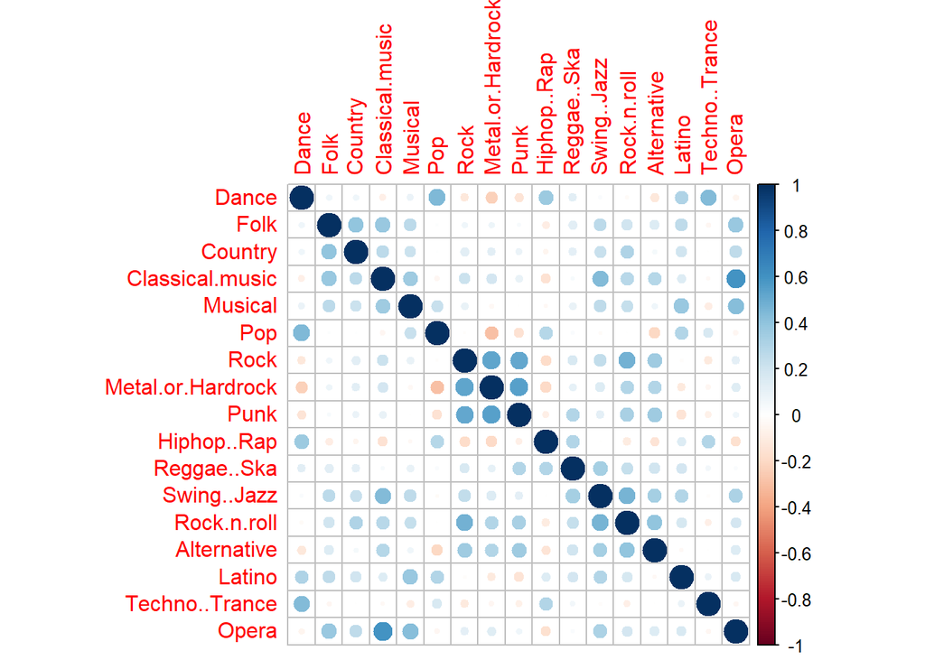

```r
library(corrplot)
music <- na.omit(music[3:length(music)]) #la primera variable es cuanto gusta la música en general y la segunda la música rápida o lenta
corrplot(cor(music))
```

Vemos que algunas correlaciones destacadas son:

- Música clásica y opera
- Rock, Metal y Punk
- Rock and roll y Rock
- Opera y musicales

Hagamos lo mismo ahora para los gustos cinematográficos:

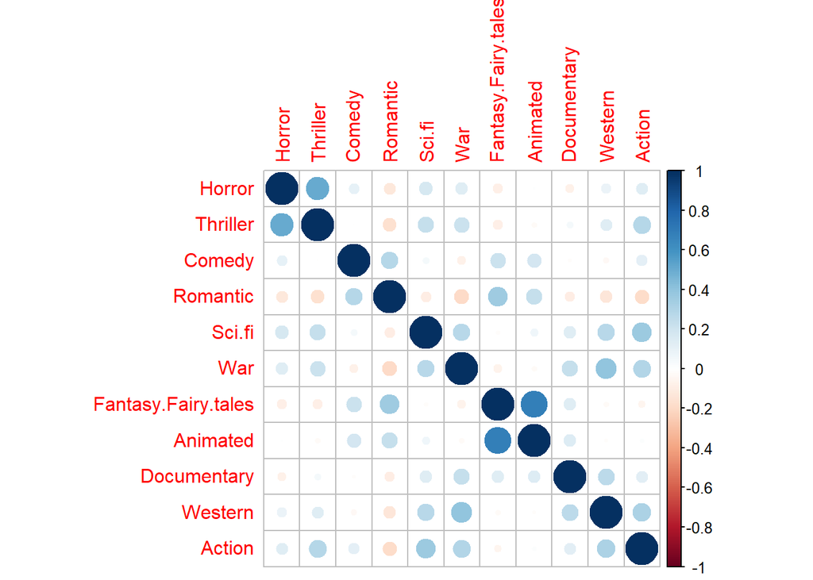

```r
movies <- na.omit(movies[2:length(movies)])
corrplot(cor(movies))
```

Aquí las correlaciones más destacadas son:

- Dibujos animados y cuentos fantásticos
- Western y películas de guerra
- Horror y thriller
- Acción y ciencia ficción

Finalmente hacemos lo mismo con los hobbies:

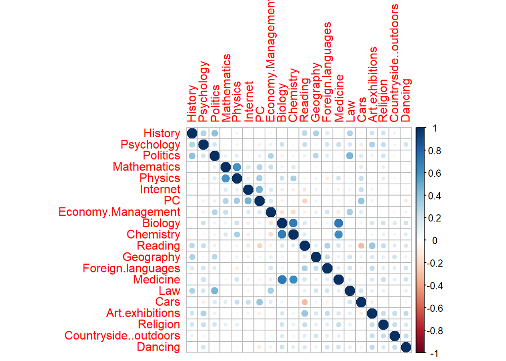

```r
hobbies <- na.omit(hobbies[1:20])
corrplot(cor(hobbies))
```

Las más destacables son:

- Medicina, química y biología
- Derecho y política
- Física y matemáticas

```r
library(ggplot2)
```

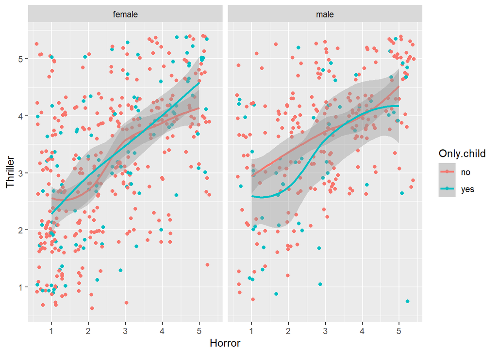

```r
ggplot(data, aes(x=Horror, y=Thriller, col=Only.child))+geom_jitter()+geom_smooth()+facet_grid(cols=vars(Gender))
```

Veamos ahora los intereses en cuanto a carrearas universitarias de hombres y mujeres:

```r
library(tidyr)
```

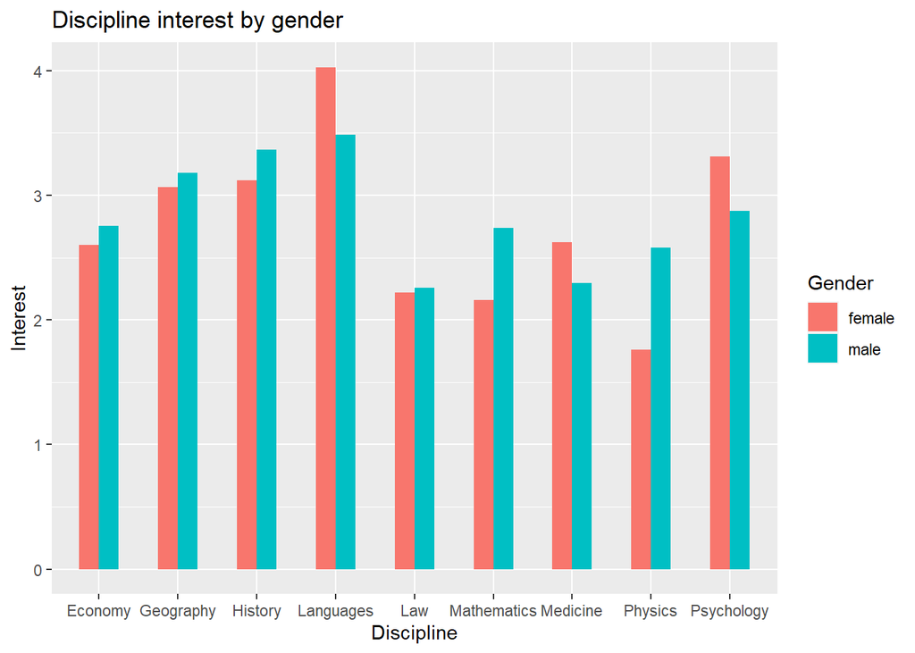

```r
grades_by_gender <- data %>% group_by(Gender) %>% summarise(
  History=mean(History),
  Psychology=mean(Psychology),
  Mathematics=mean(Mathematics),
  Physics=mean(Physics),
  Medicine=mean(Medicine),
  Law=mean(Law),
  Languages=mean(Foreign.languages),
  Geography=mean(Geography),
  Economy=mean(Economy.Management)
    )
grades_by_gender <- pivot_longer(grades_by_gender, cols=2:length(grades_by_gender), names_to="Discipline", values_to="Interest")

ggplot(grades_by_gender, aes(x=Discipline,y=Interest,fill=Gender))+geom_col(position="dodge", width=0.5)+labs(title="Discipline interest by gender")
```

Conclusiones:

- La disciplina más preferida por todo el mundo son las lenguas extranjeras
- Las disciplinas menos preferidas son física y derecho
- Las disciplinas más preferidas por mujeres que por hombres: Psicología, lenguas extranjeras y medicina
- Las disciplinas más preferidas por hombres que por mujeres: Matemáticas, física y historia
- Las disciplinas igual de preferidas: Derecho, geografía y economía

Veamos ahora un insight que si bien no es conclusivo, puede ser curioso:

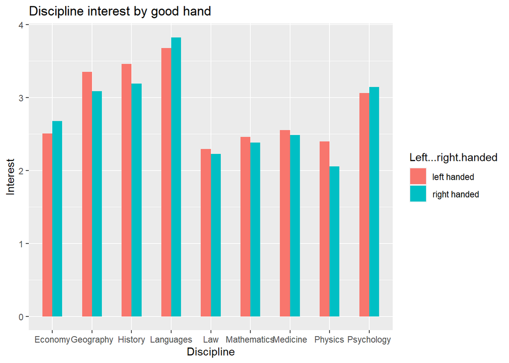

```r
grades_by_hand <- data %>% group_by(Left...right.handed) %>% summarise(
  History=mean(History),
  Psychology=mean(Psychology),
  Mathematics=mean(Mathematics),
  Physics=mean(Physics),
  Medicine=mean(Medicine),
  Law=mean(Law),
  Languages=mean(Foreign.languages),
  Geography=mean(Geography),
  Economy=mean(Economy.Management)
    )
grades_by_hand <- pivot_longer(grades_by_hand, cols=2:length(grades_by_hand), names_to="Discipline", values_to="Interest")

ggplot(grades_by_hand, aes(x=Discipline,y=Interest,fill=Left...right.handed))+geom_col(position="dodge", width=0.5)+labs(title="Discipline interest by good hand")
```

- ¿Tienen los zurdos más interés en la física que los diestros?

Estos insights dan cierta luz sobre la pregunta que nos haciamos y es que sí parece haber cierta correlación entre los gustos de las personas y su sexo pero no parece estar claro que lo haya atendiendo a la mano buena. En todo caso para poder integrar todas las variables de las que disponemos en lugar de eternizarnos haciendo gráficas para gustos musicales, opiniones, hobbies,… será mejor recurrir a técnicas para reducir las dimensiones.

## PCA

```r
pca = prcomp(select(data,-demographics_column_names), scale=T)
```

```
## Note: Using an external vector in selections is ambiguous.
## i Use `all_of(demographics_column_names)` instead of `demographics_column_names` to silence this message.
## i See <https://tidyselect.r-lib.org/reference/faq-external-vector.html>.
```

```r
summary(pca)
```

```
## Importance of components:
##                            PC1    PC2     PC3     PC4     PC5     PC6     PC7
## Standard deviation     2.90111 2.7094 2.45292 1.97116 1.93788 1.79896 1.68429
## Proportion of Variance 0.06627 0.0578 0.04738 0.03059 0.02957 0.02548 0.02234
## Cumulative Proportion  0.06627 0.1241 0.17145 0.20204 0.23161 0.25709 0.27943
##                            PC8     PC9   PC10    PC11    PC12    PC13    PC14
## Standard deviation     1.57652 1.52765 1.4695 1.44462 1.41679 1.36540 1.35321
## Proportion of Variance 0.01957 0.01838 0.0170 0.01643 0.01581 0.01468 0.01442
## Cumulative Proportion  0.29900 0.31738 0.3344 0.35081 0.36662 0.38130 0.39572
##                           PC15    PC16   PC17    PC18    PC19    PC20    PC21
## Standard deviation     1.30320 1.28609 1.2800 1.25160 1.23347 1.21701 1.19186
## Proportion of Variance 0.01337 0.01302 0.0129 0.01233 0.01198 0.01166 0.01119
## Cumulative Proportion  0.40909 0.42211 0.4350 0.44735 0.45933 0.47099 0.48218
##                           PC22    PC23    PC24    PC25    PC26    PC27    PC28
## Standard deviation     1.18106 1.16177 1.14863 1.12823 1.12238 1.10300 1.09519
## Proportion of Variance 0.01098 0.01063 0.01039 0.01002 0.00992 0.00958 0.00944
## Cumulative Proportion  0.49316 0.50379 0.51418 0.52420 0.53412 0.54370 0.55314
##                           PC29    PC30    PC31    PC32    PC33    PC34    PC35
## Standard deviation     1.08248 1.07134 1.06014 1.05523 1.04444 1.03393 1.02720
## Proportion of Variance 0.00923 0.00904 0.00885 0.00877 0.00859 0.00842 0.00831
## Cumulative Proportion  0.56237 0.57141 0.58026 0.58902 0.59761 0.60603 0.61434
##                           PC36    PC37    PC38    PC39    PC40    PC41    PC42
## Standard deviation     1.01778 1.00678 0.99799 0.99382 0.98758 0.96892 0.96464
## Proportion of Variance 0.00816 0.00798 0.00784 0.00778 0.00768 0.00739 0.00733
## Cumulative Proportion  0.62250 0.63048 0.63832 0.64610 0.65378 0.66117 0.66849
##                           PC43    PC44    PC45    PC46    PC47    PC48    PC49
## Standard deviation     0.96051 0.95473 0.93932 0.93443 0.93228 0.92165 0.91496
## Proportion of Variance 0.00726 0.00718 0.00695 0.00688 0.00684 0.00669 0.00659
## Cumulative Proportion  0.67576 0.68294 0.68988 0.69676 0.70360 0.71029 0.71688
##                           PC50    PC51   PC52    PC53   PC54    PC55    PC56
## Standard deviation     0.90674 0.89903 0.8877 0.88624 0.8803 0.87394 0.86701
## Proportion of Variance 0.00647 0.00636 0.0062 0.00618 0.0061 0.00601 0.00592
## Cumulative Proportion  0.72336 0.72972 0.7359 0.74211 0.7482 0.75423 0.76015
##                           PC57    PC58    PC59    PC60   PC61    PC62    PC63
## Standard deviation     0.86382 0.85670 0.84672 0.83681 0.8355 0.82729 0.82206
## Proportion of Variance 0.00588 0.00578 0.00565 0.00551 0.0055 0.00539 0.00532
## Cumulative Proportion  0.76602 0.77180 0.77745 0.78296 0.7885 0.79384 0.79917
##                           PC64    PC65    PC66    PC67    PC68    PC69    PC70
## Standard deviation     0.82190 0.80713 0.80045 0.79288 0.78991 0.78019 0.77486
## Proportion of Variance 0.00532 0.00513 0.00505 0.00495 0.00491 0.00479 0.00473
```

[output cut: 22 more lines]

```
## Standard deviation     0.56159 0.55988 0.55425 0.54781 0.53511 0.53005 0.52766
## Proportion of Variance 0.00248 0.00247 0.00242 0.00236 0.00225 0.00221 0.00219
## Cumulative Proportion  0.96000 0.96246 0.96488 0.96725 0.96950 0.97171 0.97391
##                          PC113   PC114   PC115   PC116   PC117   PC118   PC119
## Standard deviation     0.52078 0.51740 0.50822 0.49690 0.49231 0.48810 0.47947
## Proportion of Variance 0.00214 0.00211 0.00203 0.00194 0.00191 0.00188 0.00181
## Cumulative Proportion  0.97604 0.97815 0.98018 0.98213 0.98403 0.98591 0.98772
##                          PC120   PC121   PC122   PC123   PC124   PC125  PC126
## Standard deviation     0.46848 0.46142 0.45520 0.44904 0.43869 0.43551 0.4218
## Proportion of Variance 0.00173 0.00168 0.00163 0.00159 0.00152 0.00149 0.0014
## Cumulative Proportion  0.98945 0.99113 0.99276 0.99434 0.99586 0.99735 0.9988
##                          PC127
## Standard deviation     0.39776
## Proportion of Variance 0.00125
## Cumulative Proportion  1.00000
```

Veamos que hay en la PC1

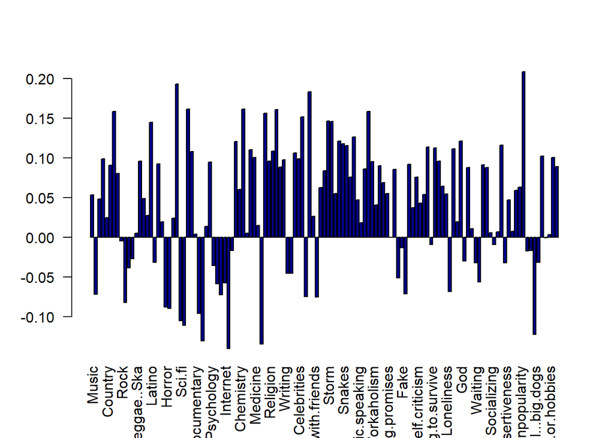

```r
barplot(pca$rotation[,1], las=2, col="darkblue")
```

Como hay muchas variables el gráfico es indescifrable. Vamos a quedarnos con las columnas con un valor por encima de un determinado umbral que fijamos a “ojo”, es decir, lo vamos ajustando hasta quedarnos con 10 variables.

```r
component_1_logical <- abs(pca$rotation[,1]) > 0.148
pc_1 <- colnames(select(data,-demographics_column_names))[component_1_logical]
pc_1
```

```
##  [1] "Musical"             "Romantic"            "Fantasy.Fairy.tales"
##  [4] "Reading"             "Art.exhibitions"     "Dancing"
##  [7] "Shopping"            "Theatre"             "Writing.notes"
## [10] "Life.struggles"
```

```r
component_2_logical <- abs(pca$rotation[,2]) > 0.1459
pc_2 <- colnames(select(data,-demographics_column_names))[component_2_logical]
pc_2
```

```
##  [1] "Classical.music"        "Swing..Jazz"            "Rock.n.roll"
##  [4] "Opera"                  "Documentary"            "Western"
##  [7] "History"                "Physics"                "Science.and.technology"
## [10] "Interests.or.hobbies"
```

```r
component_3_logical <- abs(pca$rotation[,3]) > 0.165
pc_3 <- colnames(select(data,-demographics_column_names))[component_3_logical]
pc_3
```

```
## [1] "Dance"             "Hiphop..Rap"       "Shopping"
## [4] "Fun.with.friends"  "Number.of.friends" "Socializing"
## [7] "Happiness.in.life" "Energy.levels"     "Personality"
```

```r
component_4_logical <- abs(pca$rotation[,4]) > 0.14965
pc_4 <- colnames(select(data,-demographics_column_names))[component_4_logical]
pc_4
```

```
##  [1] "Horror"            "Thriller"          "Internet"
##  [4] "Celebrities"       "Ageing"            "Criminal.damage"
##  [7] "Loneliness"        "Changing.the.past" "Getting.angry"
## [10] "Happiness.in.life"
```

Vemos como aproximadamente las tres primeras componentes principales están describiendo 3 personalidades muy definidas:

Es curioso que cada una de las pc se pueda asociar aproximadamente a cada una de las principales personalidades que se usan en los test psicológicos actualmente:

- pc_1: emocional-introvertido (comprensivo, conciliador, paciente)
- pc_2: racional-introvertido (objetivo, analítico, metódico)
- pc_3: emocional-extrovertido (espontáneo, sociable, comunicativo)
- pc_4: racional-extrovertido (directo, dominante, competitivo)

Más adelante comprobaremos si estos perfiles se corresponden con el género, zurdo/diestro, pueblo/ciudad, edad,…

Antes, visualicemos las aportaciones de cada variable a las componentes:

```r
library(GGally)
library(factoextra)
```

Nuevamente, al haber muchas variables no se puede ver nada

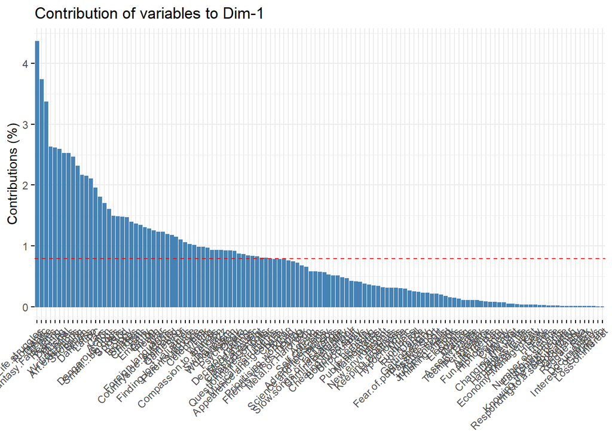

```r
fviz_contrib(pca, choice = "var", axes = 1)
```

Nos fabricamos el gráfico con las variables con más contribucion

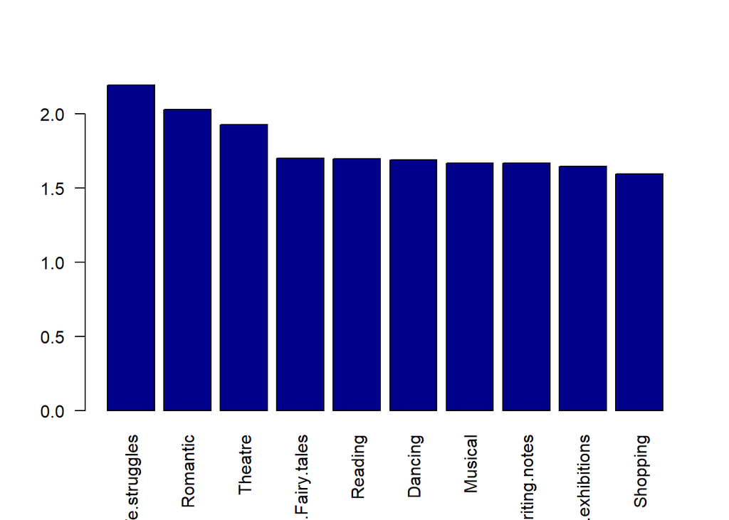

```r
contribution_percentage_pc1 <- (abs(pca$rotation[,1]*100))/sum(abs(pca$rotation[,1]))
sorted_contributions_pc1 <- sort(contribution_percentage_pc1[component_1_logical], decreasing=TRUE)
barplot(sorted_contributions_pc1, las=2, col="darkblue")
```

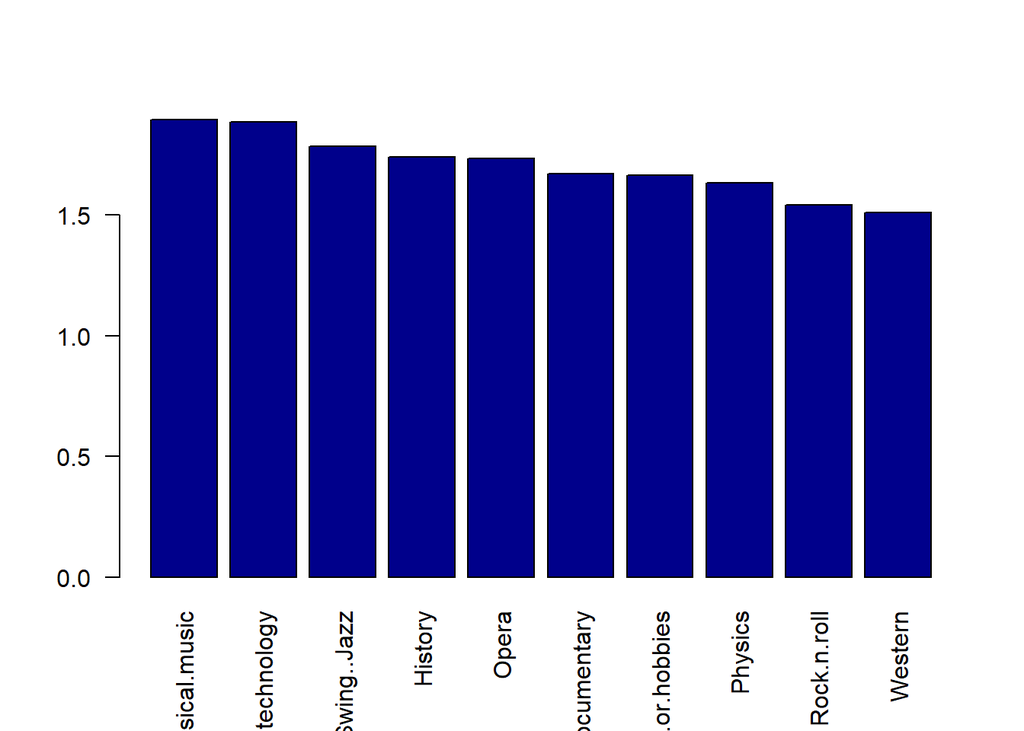

```r
contribution_percentage_pc2 <- (abs(pca$rotation[,2]*100))/sum(abs(pca$rotation[,2]))
sorted_contributions_pc2 <- sort(contribution_percentage_pc2[component_2_logical], decreasing=TRUE)
barplot(sorted_contributions_pc2, las=2, col="darkblue")
```

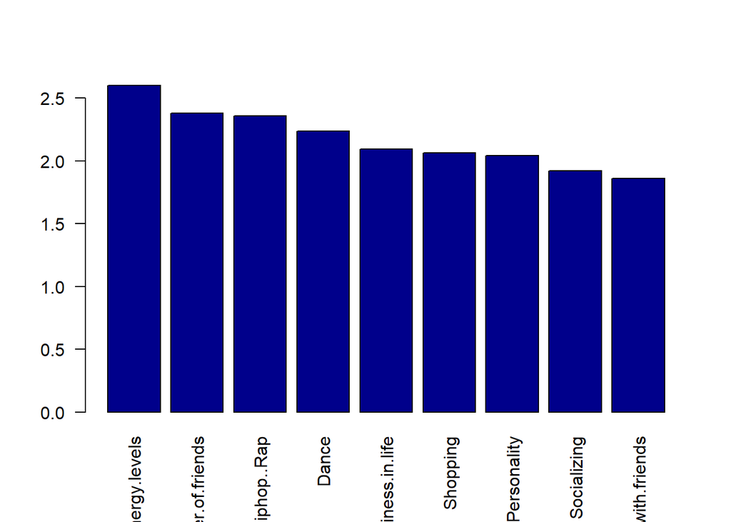

```r
contribution_percentage_pc3 <- (abs(pca$rotation[,3]*100))/sum(abs(pca$rotation[,3]))
sorted_contributions_pc3 <- sort(contribution_percentage_pc3[component_3_logical], decreasing=TRUE)
barplot(sorted_contributions_pc3, las=2, col="darkblue")
```

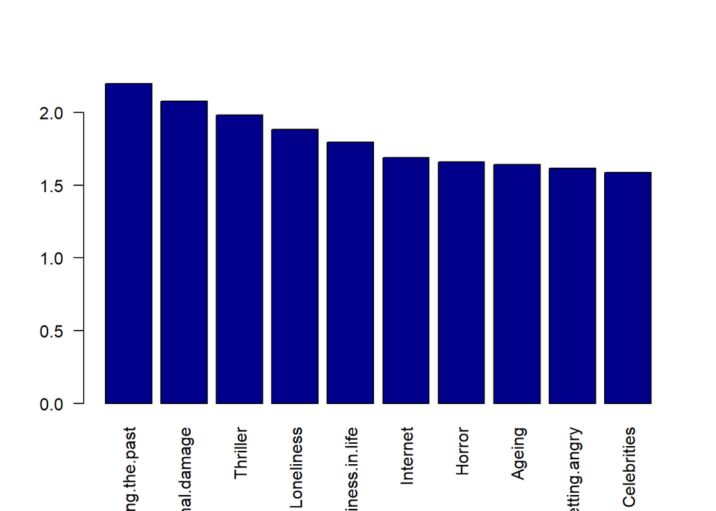

```r
contribution_percentage_pc4 <- (abs(pca$rotation[,4]*100))/sum(abs(pca$rotation[,4]))
sorted_contributions_pc4 <- sort(contribution_percentage_pc4[component_4_logical], decreasing=TRUE)
barplot(sorted_contributions_pc4, las=2, col="darkblue")
```

Sabiendo ahora cuales son las componentes principales vamos a visualizar gráficos en los que se contrapongan dos componentes principales y coloreemos cada punto según las siguientes variables que en ningún caso han sido usadas para calcular las componentes principales (recordemos que hemos quitado todas las variables demográficas antes de llamar a la función “prcom”):

- Sexo
- Edad
- Zurdo/diestro
- Educación
- Hijo único
- Pueblo/ciudad

```r
library(ggplot2)
```

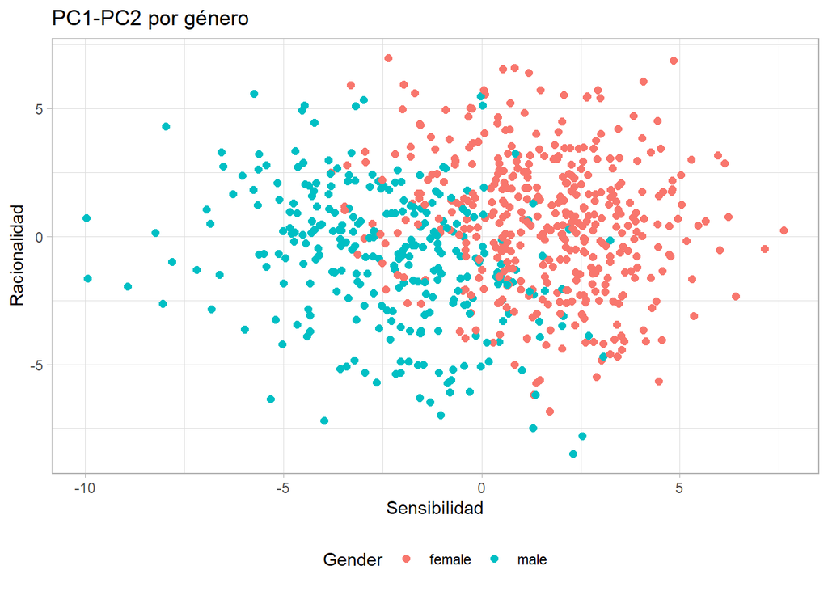

```r
data.frame(z1=pca$x[,1],z2=pca$x[,2], Gender=data$Gender) %>%
  ggplot(aes(z1,z2,color=Gender)) + geom_point(size=2) +
  labs(title="PC1-PC2 por género", x="Sensibilidad", y="Racionalidad") + #guides(color=guide_legend(title="HDI"))+
    theme_light()  +theme(legend.position="bottom")
```

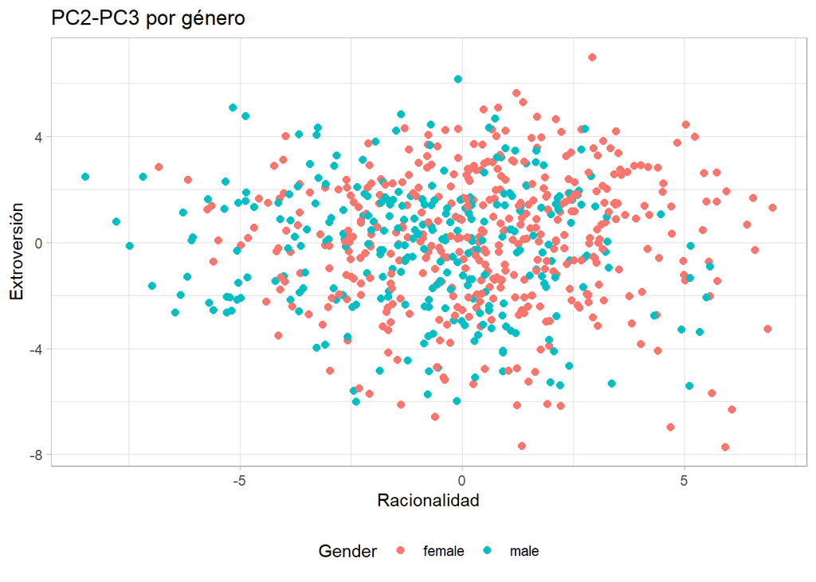

```r
data.frame(z1=pca$x[,2],z2=pca$x[,3], Gender=data$Gender) %>%
  ggplot(aes(z1,z2,color=Gender)) + geom_point(size=2) +
  labs(title="PC2-PC3 por género", x="Racionalidad", y="Extroversión") + #guides(color=guide_legend(title="HDI"))+
    theme_light()  +theme(legend.position="bottom")
```

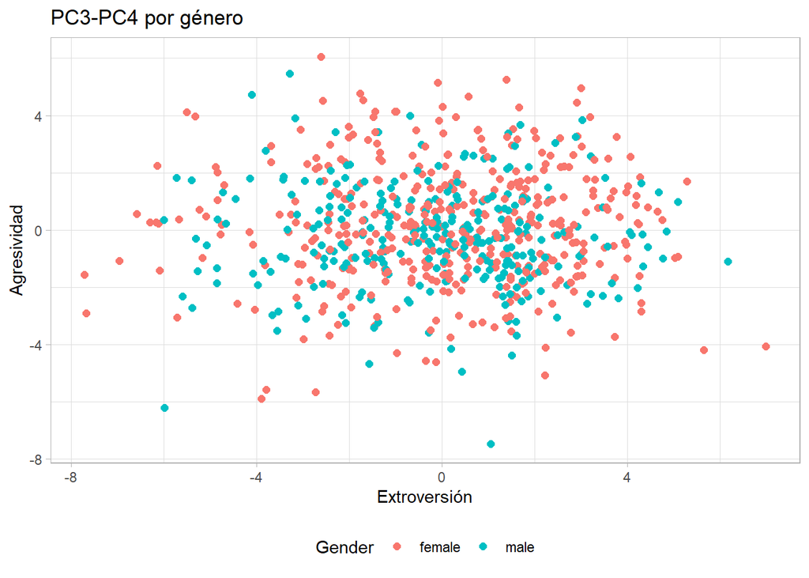

```r
data.frame(z1=pca$x[,3],z2=pca$x[,4], Gender=data$Gender) %>%
  ggplot(aes(z1,z2,color=Gender)) + geom_point(size=2) +
  labs(title="PC3-PC4 por género", x="Extroversión", y="Agresividad") + #guides(color=guide_legend(title="HDI"))+
    theme_light()  +theme(legend.position="bottom")
```

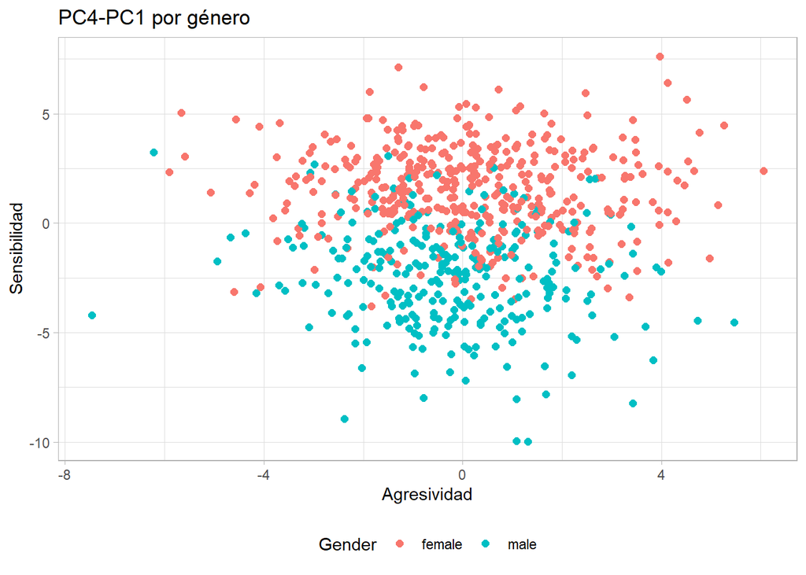

```r
data.frame(z1=pca$x[,4],z2=pca$x[,1], Gender=data$Gender) %>%
  ggplot(aes(z1,z2,color=Gender)) + geom_point(size=2) +
  labs(title="PC4-PC1 por género", x="Agresividad", y="Sensibilidad") + #guides(color=guide_legend(title="HDI"))+
    theme_light()  +theme(legend.position="bottom")
```

Siguiendo esta misma estrategia (ver los tres gráficos que relacionan pc1, pc2, pc3 y pc4) miramos el resto de variables. Solo se muestran a partir de ahora los gráficos más relevantes si es que los hay.

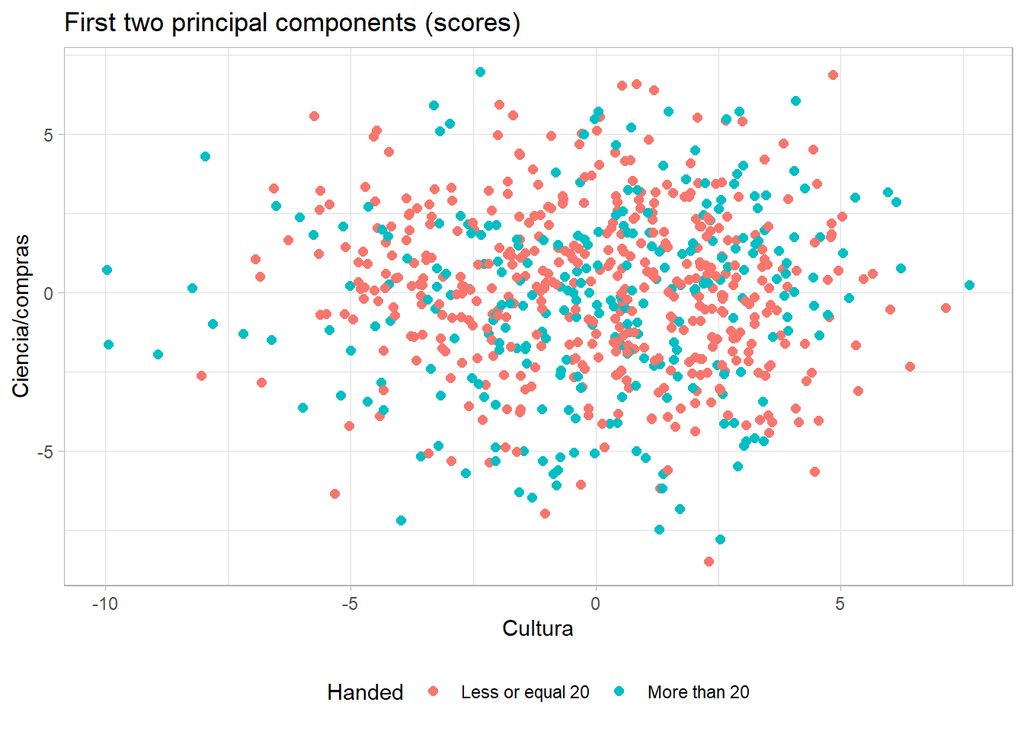

```r
data.frame(z1=pca$x[,1],z2=pca$x[,2], Handed=data$Age) %>%
  ggplot(aes(z1,z2,color=Handed)) + geom_point(size=2) +
  labs(title="First two principal components (scores)", x="Cultura", y="Ciencia/compras") + #guides(color=guide_legend(title="HDI"))+
    theme_light()  +theme(legend.position="bottom")
```

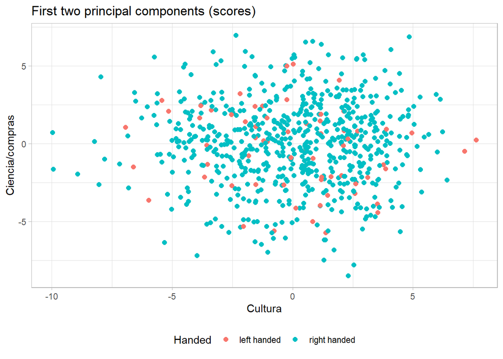

```r
data.frame(z1=pca$x[,1],z2=pca$x[,2], Handed=data$Left...right.handed) %>%
  ggplot(aes(z1,z2,color=Handed)) + geom_point(size=2) +
  labs(title="First two principal components (scores)", x="Cultura", y="Ciencia/compras") + #guides(color=guide_legend(title="HDI"))+
    theme_light()  +theme(legend.position="bottom")
```

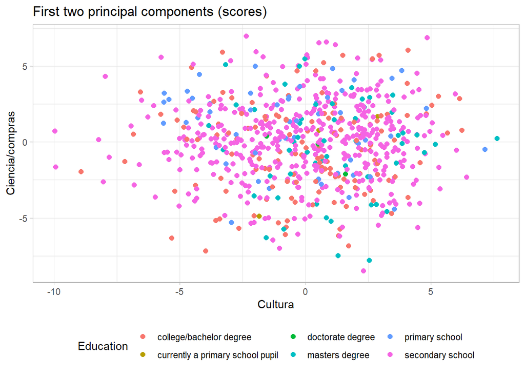

```r
data.frame(z1=pca$x[,1],z2=pca$x[,2], Education=data$Education) %>%
  ggplot(aes(z1,z2,color=Education)) + geom_point(size=2) +
  labs(title="First two principal components (scores)", x="Cultura", y="Ciencia/compras") + #guides(color=guide_legend(title="HDI"))+
    theme_light()  +theme(legend.position="bottom")
```

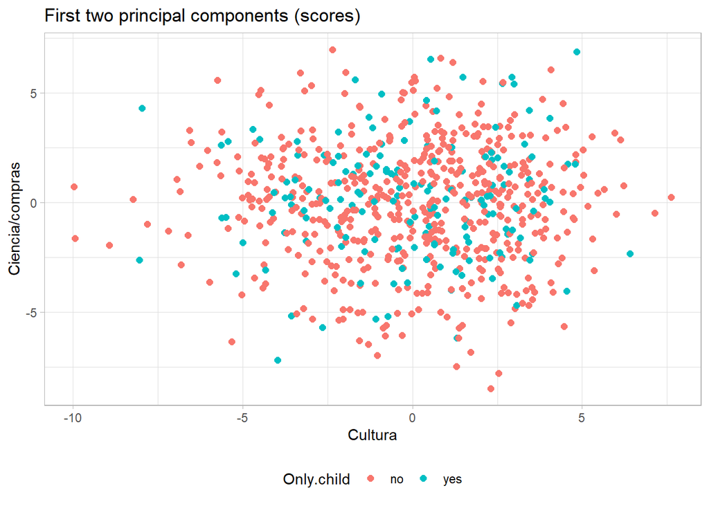

```r
data.frame(z1=pca$x[,1],z2=pca$x[,2], Only.child=data$Only.child) %>%
  ggplot(aes(z1,z2,color=Only.child)) + geom_point(size=2) +
  labs(title="First two principal components (scores)", x="Cultura", y="Ciencia/compras") + #guides(color=guide_legend(title="HDI"))+
    theme_light()  +theme(legend.position="bottom")
```

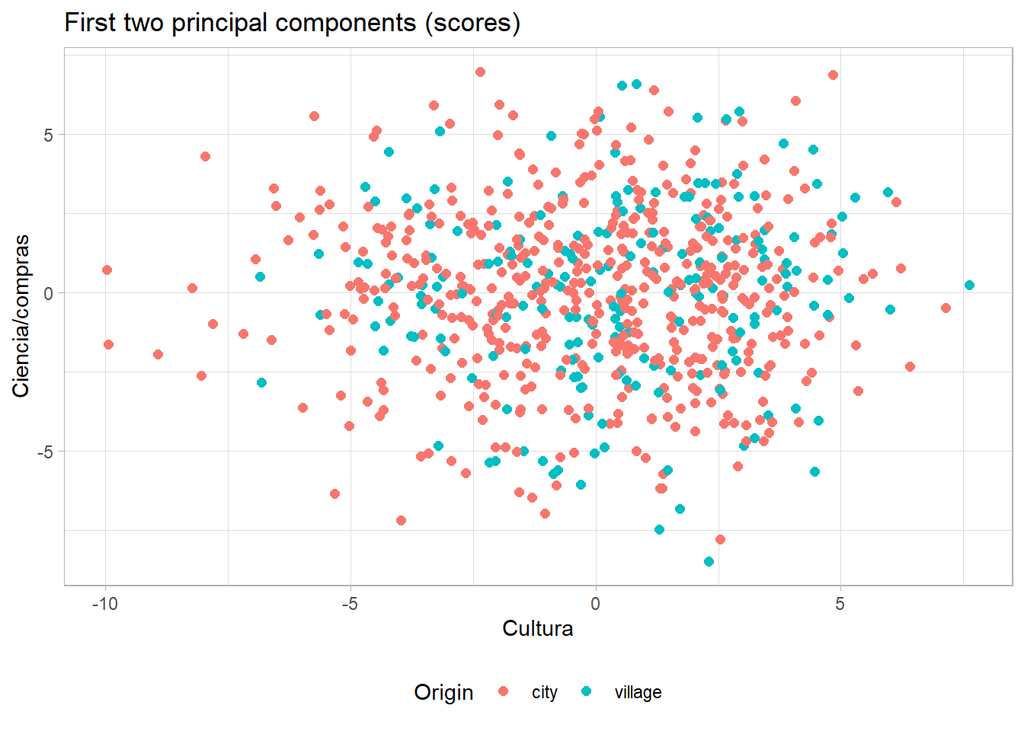

```r
data.frame(z1=pca$x[,1],z2=pca$x[,2], Origin=data$Village...town) %>%
  ggplot(aes(z1,z2,color=Origin)) + geom_point(size=2) +
  labs(title="First two principal components (scores)", x="Cultura", y="Ciencia/compras") + #guides(color=guide_legend(title="HDI"))+
    theme_light()  +theme(legend.position="bottom")
```

Comprobamos que aparte del sexo no parece haber relación entre las pc y las variables edad, zurdo/diestro, hijo único y pueblo/ciudad.

Antes de sacar conclusiones hacemos otro tipo de visualización por si se nos hubiese escapado algo.

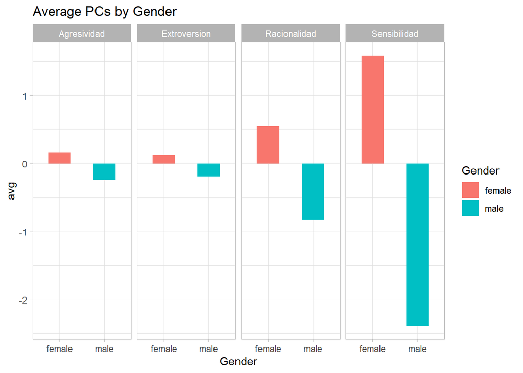

```r
pc_avgs <- data.frame(z1=pca$x[,1],z2=pca$x[,2],z3=pca$x[,3],z4=pca$x[,4], Gender=data$Gender) %>%
  group_by(Gender) %>%
  summarise(Sensibilidad=mean(z1), Racionalidad=mean(z2), Extroversion=mean(z3), Agresividad=mean(z4))

pc_avgs <- pivot_longer(pc_avgs, cols=2:5, names_to="pc", values_to="avg")

ggplot(data=pc_avgs, aes(x=Gender,y=avg,fill=Gender)) +
  geom_col(width=0.5)  +
  facet_grid(cols = vars(pc)) +
  theme_light() +labs(title="Average PCs by Gender")
```

Insights:

- Las mujeres son más sensibles y racionales que los hombres.
- Hombres y mujeres son a partes iguales agresivos y extrovertidos

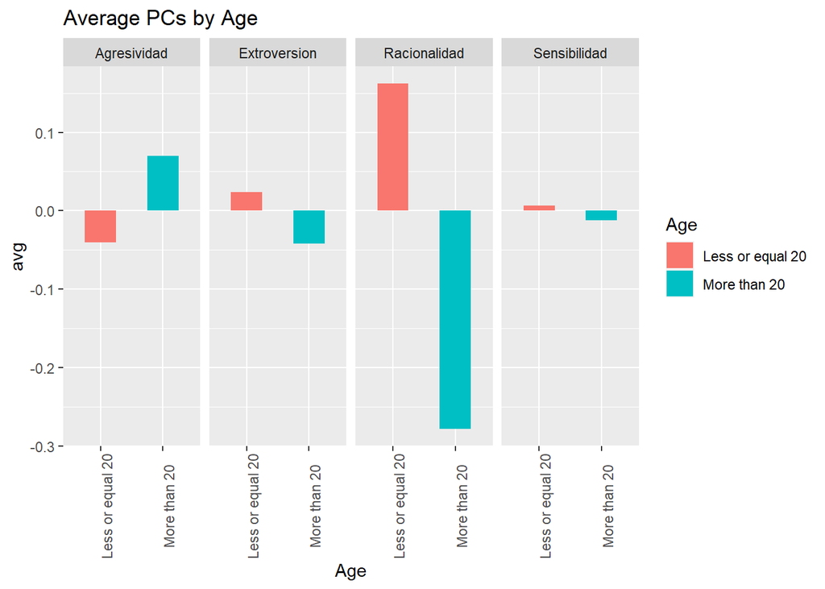

```r
pc_avgs <- data.frame(z1=pca$x[,1],z2=pca$x[,2],z3=pca$x[,3],z4=pca$x[,4], Age=data$Age) %>%
  group_by(Age) %>%
  summarise(Sensibilidad=mean(z1), Racionalidad=mean(z2), Extroversion=mean(z3), Agresividad=mean(z4))

pc_avgs <- pivot_longer(pc_avgs, cols=2:5, names_to="pc", values_to="avg")

ggplot(data=pc_avgs, aes(x=Age,y=avg,fill=Age)) +
  geom_col(width=0.5,)  +
  facet_grid(cols = vars(pc)) +
  theme(axis.text.x = element_text(angle = 90)) +labs(title="Average PCs by Age")
```

Insights:

- La principal diferencia entre personas de más y menos que 20 años es la racionalidad. Sorprendentemente las personas de menos de 20 años son más racionales, no obstante hay que tener en cuenta que la encuesta está hecha en perfiles entre 16 y 26 años.

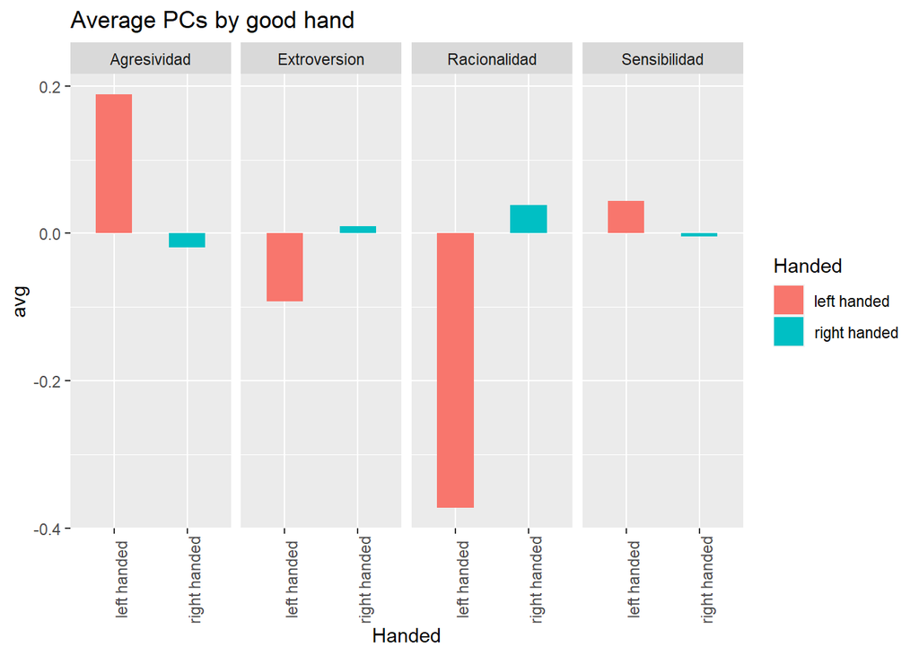

```r
pc_avgs <- data.frame(z1=pca$x[,1],z2=pca$x[,2],z3=pca$x[,3],z4=pca$x[,4], Handed=data$Left...right.handed) %>%
  group_by(Handed) %>%
  summarise(Sensibilidad=mean(z1), Racionalidad=mean(z2), Extroversion=mean(z3), Agresividad=mean(z4))

pc_avgs <- pivot_longer(pc_avgs, cols=2:5, names_to="pc", values_to="avg")

ggplot(data=pc_avgs, aes(x=Handed,y=avg,fill=Handed)) +
  geom_col(width=0.5,)  +
  facet_grid(cols = vars(pc)) +
  theme(axis.text.x = element_text(angle = 90)) +labs(title="Average PCs by good hand")
```

Insights:

- Los zurdos son poco racionales. Esto puede encajar con la teoría de que los zurdos son más creativos que los diestros o simplemente puede reflejar que la muestra de zurdos encuestados es tan pequeña que está sesgada.

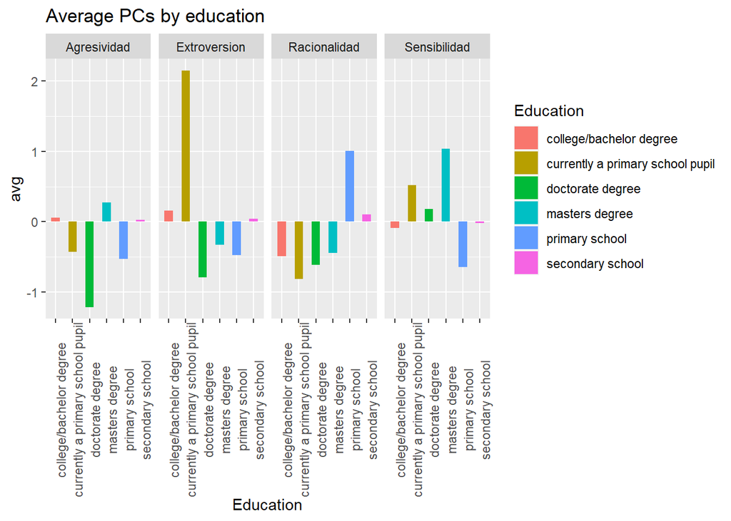

```r
pc_avgs <- data.frame(z1=pca$x[,1],z2=pca$x[,2],z3=pca$x[,3],z4=pca$x[,4], Education=data$Education) %>%
  group_by(Education) %>%
  summarise(Sensibilidad=mean(z1), Racionalidad=mean(z2), Extroversion=mean(z3), Agresividad=mean(z4))

pc_avgs <- pivot_longer(pc_avgs, cols=2:5, names_to="pc", values_to="avg")

ggplot(data=pc_avgs, aes(x=Education,y=avg,fill=Education)) +
  geom_col(width=0.5,)  +
  facet_grid(cols = vars(pc)) +
  theme(axis.text.x = element_text(angle = 90)) +labs(title="Average PCs by education")
```

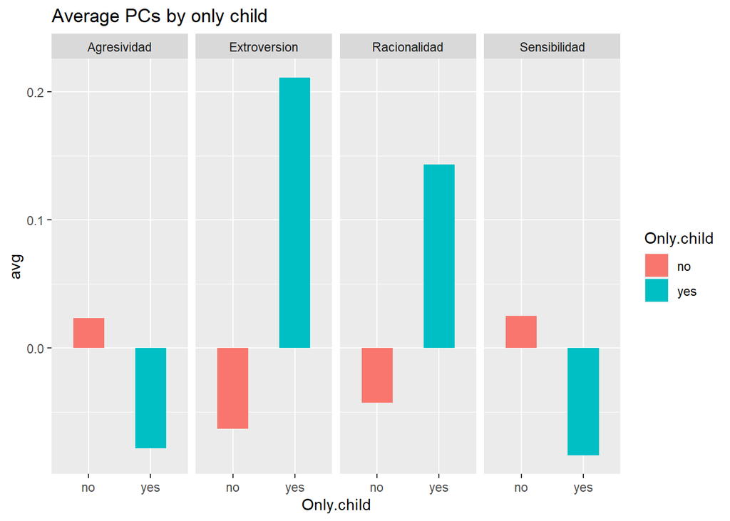

```r
pc_avgs <- data.frame(z1=pca$x[,1],z2=pca$x[,2],z3=pca$x[,3],z4=pca$x[,4], Only.child=data$Only.child) %>%
  group_by(Only.child) %>%
  summarise(Sensibilidad=mean(z1), Racionalidad=mean(z2), Extroversion=mean(z3), Agresividad=mean(z4))

pc_avgs <- pivot_longer(pc_avgs, cols=2:5, names_to="pc", values_to="avg")

ggplot(data=pc_avgs, aes(x=Only.child,y=avg,fill=Only.child)) +
  geom_col(width=0.5,)  +
  facet_grid(cols = vars(pc)) +
  theme() +labs(title="Average PCs by only child")
```

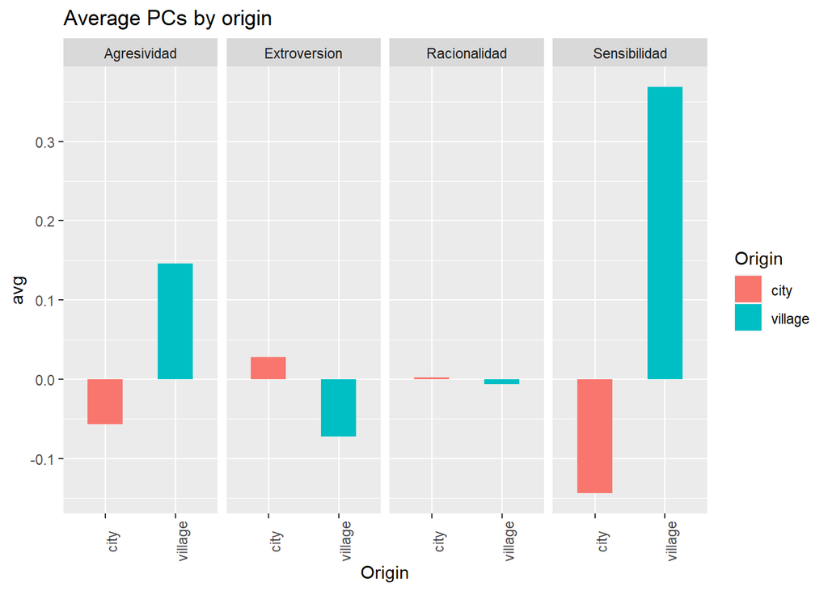

```r
pc_avgs <- data.frame(z1=pca$x[,1],z2=pca$x[,2],z3=pca$x[,3],z4=pca$x[,4], Origin=data$Village...town) %>%
  group_by(Origin) %>%
  summarise(Sensibilidad=mean(z1), Racionalidad=mean(z2), Extroversion=mean(z3), Agresividad=mean(z4))

pc_avgs <- pivot_longer(pc_avgs, cols=2:5, names_to="pc", values_to="avg")

ggplot(data=pc_avgs, aes(x=Origin,y=avg,fill=Origin)) +
  geom_col(width=0.5,)  +
  facet_grid(cols = vars(pc)) +
  theme(axis.text.x = element_text(angle = 90)) +labs(title="Average PCs by origin")
```

Como conclusión general y respuesta a la pregunta que nos planteábamos. En general, tu sexo, edad, origen, etc. no definen completamente quien eres pero tienen un impacto fuerte en algunos aspectos de la personalidad.

No obstante no todo es de color de rosa. A continuación vemos un pequeño análisis del porcentaje de la varianza que explican las 4 primeras componentes principales:

```r
var_explained <- pca$sdev^2 / sum(pca$sdev^2)
```

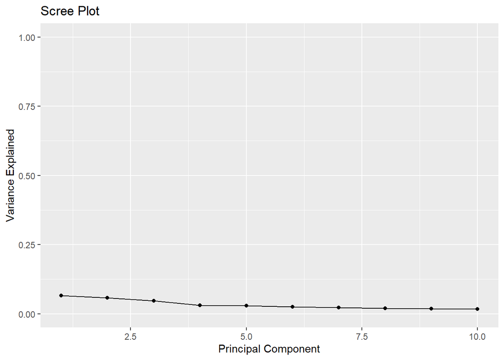

```r
qplot(c(1:10), var_explained[1:10]) +
  geom_line() +
  xlab("Principal Component") +
  ylab("Variance Explained") +
  ggtitle("Scree Plot") +
  ylim(0, 1)
```

Total de varianza explicada por las 4 primeras PC:

```r
sum(var_explained[1:4])
```

```
## [1] 0.2020419
```

Aunque 0.2 pueda parecer una parte muy pequeña de la varianza, nos ha servido para diferenciar 4 componentes principales que tienen sentido (cada una es un rasgo de la personalidad) y para separar basándonos en algunas de ellas a hombres y mujeres.

## FA

Para hacer FA vemos que nos encontramos con el mismo problema del porcentaje de varianza explicado. Para llegar a 0.5 necesitamos 40 factores. Omito el cálculo porque la salida es muy grande.

Vamos a hacer el FA con 5 factores que explican una quinta parte de la varianza (al igual que pasaba con PC). Parece ambicioso intentar reducir los rasgos de la personalidad a 5 valores pero en PC hemos obtenido resultados aceptables:

```r
x.f <- factanal(select(data, -demographics_column_names), factors = 5, rotation="none", scores="regression")
x.f
```

```
##
## Call:
## factanal(x = select(data, -demographics_column_names), factors = 5,     scores = "regression", rotation = "none")
##
## Uniquenesses:
##                          Music       Slow.songs.or.fast.songs
##                          0.915                          0.940
##                          Dance                           Folk
##                          0.695                          0.790
##                        Country                Classical.music
##                          0.853                          0.558
##                        Musical                            Pop
##                          0.736                          0.717
##                           Rock              Metal.or.Hardrock
##                          0.746                          0.692
##                           Punk                    Hiphop..Rap
##                          0.811                          0.700
##                    Reggae..Ska                    Swing..Jazz
##                          0.883                          0.662
##                    Rock.n.roll                    Alternative
##                          0.713                          0.641
##                         Latino                 Techno..Trance
##                          0.754                          0.852
##                          Opera                         Movies
##                          0.664                          0.892
##                         Horror                       Thriller
##                          0.858                          0.814
##                         Comedy                       Romantic
##                          0.858                          0.629
##                         Sci.fi                            War
##                          0.735                          0.772
##            Fantasy.Fairy.tales                       Animated
##                          0.787                          0.889
##                    Documentary                        Western
##                          0.765                          0.755
##                         Action                        History
##                          0.706                          0.776
##                     Psychology                       Politics
##                          0.840                          0.851
##                    Mathematics                        Physics
```

[output cut: 217 more lines]

```
## Personality                    -0.100           0.433  -0.144
## Finding.lost.valuables          0.261   0.128          -0.159
## Getting.up                             -0.121           0.316
## Interests.or.hobbies                    0.379   0.355          -0.156
## Parents..advice                 0.258                  -0.119   0.148
## Questionnaires.or.polls         0.230
##
##                Factor1 Factor2 Factor3 Factor4 Factor5
## SS loadings      7.641   6.578   5.301   3.066   3.033
## Proportion Var   0.060   0.052   0.042   0.024   0.024
## Cumulative Var   0.060   0.112   0.154   0.178   0.202
##
## Test of the hypothesis that 5 factors are sufficient.
## The chi square statistic is 17657.33 on 7376 degrees of freedom.
## The p-value is 0
```

Nuevamente no podemos visualizar el aporte de todas las variables a cada factor a la vez:

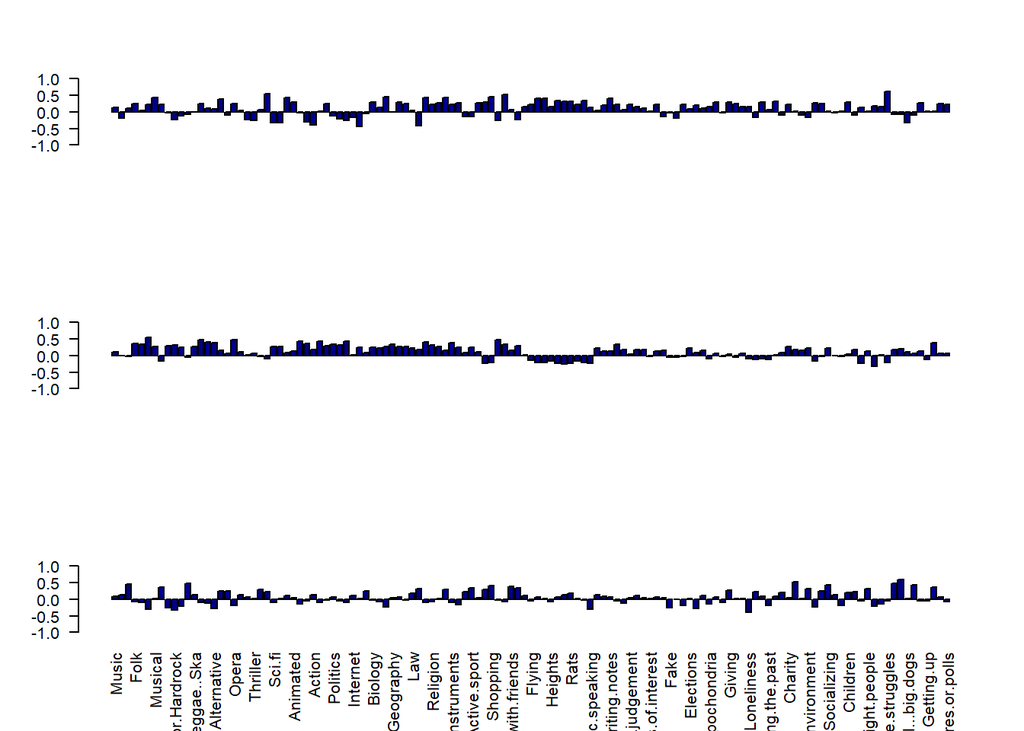

```r
par(mfrow=c(3,1))
barplot(x.f$loadings[,1], names=F, las=2, col="darkblue", ylim = c(-1, 1))
barplot(x.f$loadings[,2], names=F, las=2, col="darkblue", ylim = c(-1, 1))
barplot(x.f$loadings[,3], las=2, col="darkblue", ylim = c(-1, 1))
```

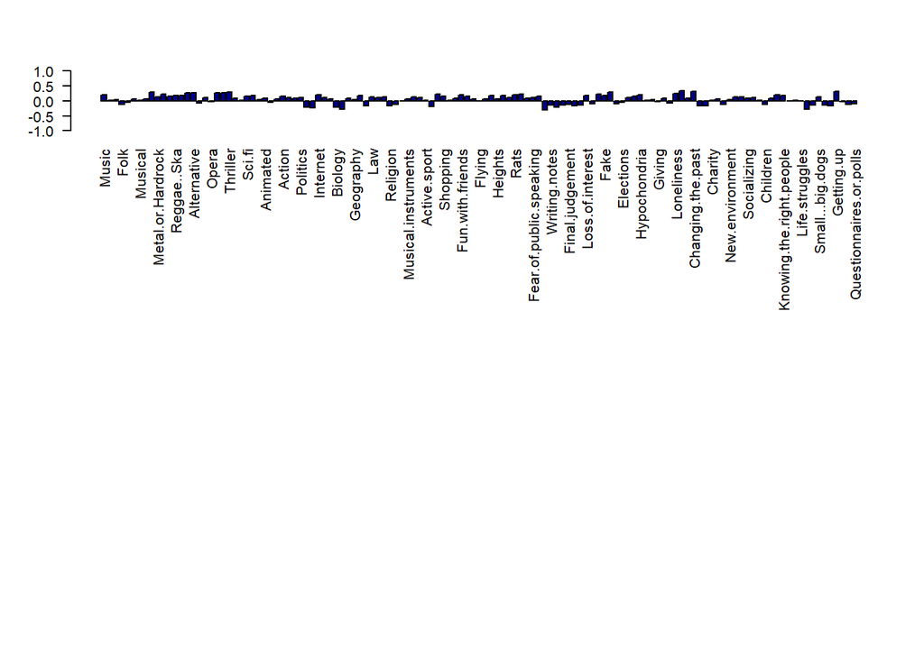

```r
barplot(x.f$loadings[,4], las=2, col="darkblue", ylim = c(-1, 1))
```

```r
plot_factor <- function(n_factor, threshold){
  factor_logical <- abs(x.f$loadings[,n_factor]) > threshold
  f <- colnames(select(data,-demographics_column_names))[factor_logical]
  print(paste("Factor ", n_factor, sep="", collapse=NULL) )
  print(f)
  contribution_percentage_f <- (x.f$loadings[,n_factor]*100)/sum(abs(x.f$loadings[,n_factor]))
  sorted_contributions_f <- sort(contribution_percentage_f[factor_logical], decreasing=TRUE)
  return(barplot(sorted_contributions_f, las=2, col="darkblue"))
}
```

```
## [1] "Factor 1"
##  [1] "Musical"             "Romantic"            "Fantasy.Fairy.tales"
##  [4] "PC"                  "Reading"             "Art.exhibitions"
##  [7] "Dancing"             "Shopping"            "Theatre"
## [10] "Life.struggles"
```

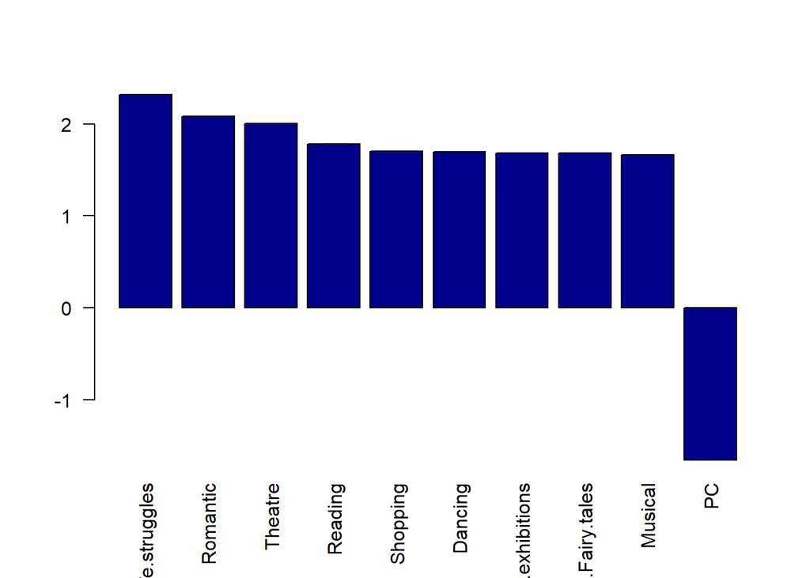

```r
plot_factor(1, 0.42)
```

```
## [1] "Factor 2"
## [1] "Classical.music"        "Swing..Jazz"            "Rock.n.roll"
## [4] "Opera"                  "Documentary"            "History"
## [7] "Physics"                "Art.exhibitions"        "Science.and.technology"
```

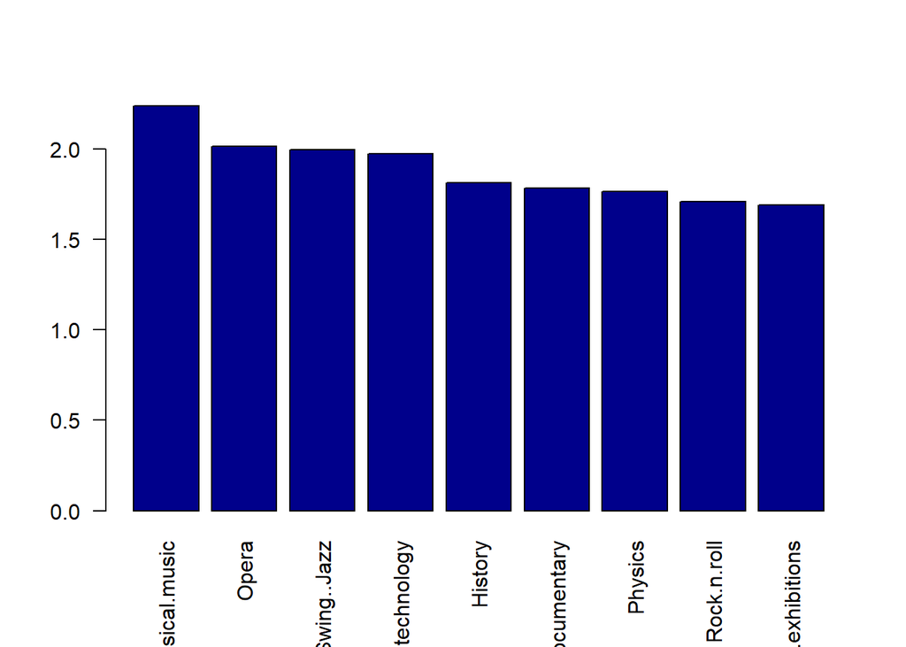

```r
plot_factor(2, 0.4)
```

```
## [1] "Factor 3"
## [1] "Dance"             "Hiphop..Rap"       "Shopping"
## [4] "Loneliness"        "Number.of.friends" "Socializing"
## [7] "Happiness.in.life" "Energy.levels"     "Personality"
```

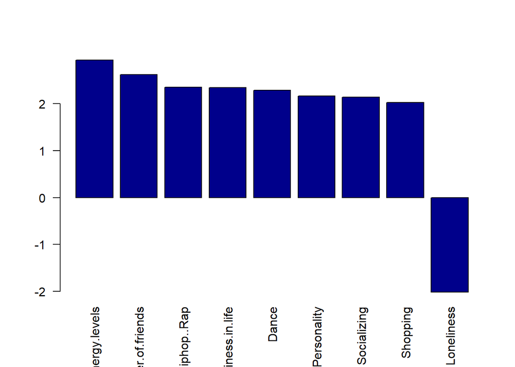

```r
plot_factor(3, 0.4)
```

```
## [1] "Factor 4"
##  [1] "Rock"                  "Rock.n.roll"           "Movies"
##  [4] "Thriller"              "Chemistry"             "Prioritising.workload"
##  [7] "Criminal.damage"       "Cheating.in.school"    "Changing.the.past"
## [10] "Happiness.in.life"     "Getting.up"
```

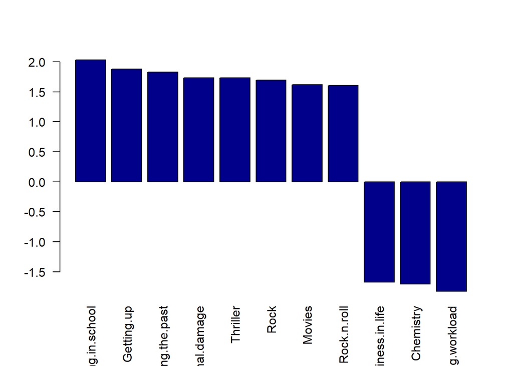

```r
plot_factor(4, 0.27)
```

```
## [1] "Factor 5"
##  [1] "Dance"                  "Pop"                    "Mathematics"
##  [4] "Physics"                "Internet"               "PC"
##  [7] "Cars"                   "Science.and.technology" "Thinking.ahead"
## [10] "Health"                 "Public.speaking"
```

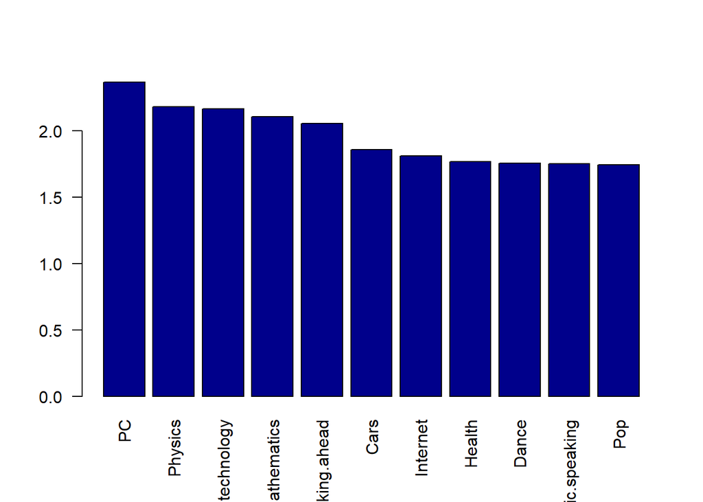

```r
plot_factor(5, 0.27)
```

Constatamos que los factores coinciden ampliamente con el análisis de las PC que recordemos brevemente como era (para verlo más detallado volver a la interpretación de las PC porque es prácticamente ideéntico):

- factor 1: Sensibilidad (Romanticismo, danza, exhibiciones artísticas, Life.strugles ~ I cry when I feel down or things don’t go the right way.)
- factor 2: Racional / ciencias-humanidades (Historia, documentales, opera, física)
- factor 3: Extroversión (Bailar, felicidad, amigos, socializar)
- factor 4: Agresividad (thriller, cheating.in.school, changin.the.past ~ I wish I could change the past because of the things I have done., criminal.damage ~ I damaged things in the past when angry.)
- factor 5: Racional / Ciencias-ingeniería (PC, Physics, Mathematics, Cars, Internet)

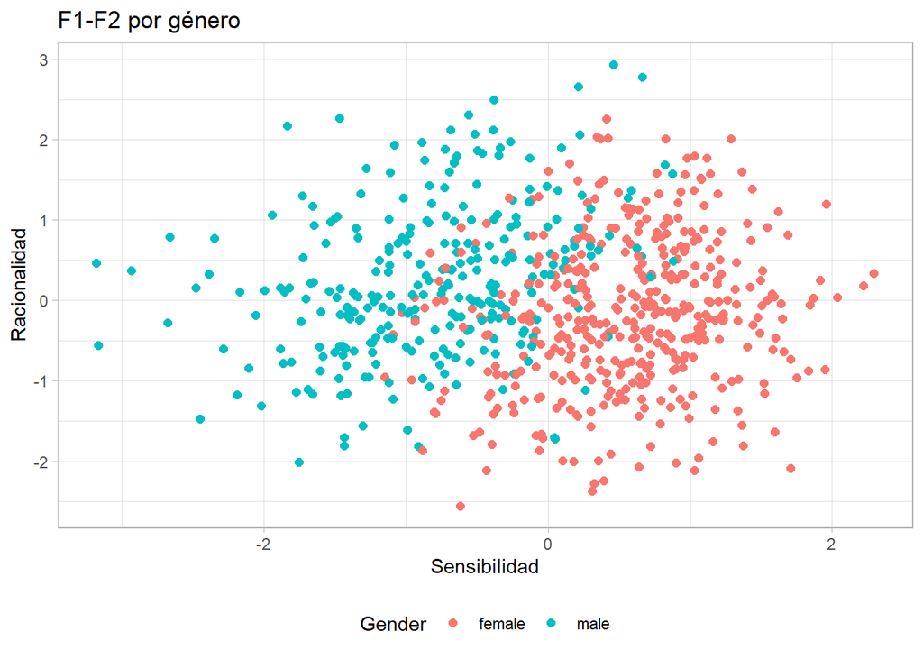

```r
data.frame(z1=x.f$scores[,1],z2=x.f$scores[,2], Gender=data$Gender) %>%
  ggplot(aes(z1,z2,color=Gender)) + geom_point(size=2) +
  labs(title="F1-F2 por género", x="Sensibilidad", y="Racionalidad") + #guides(color=guide_legend(title="HDI"))+
    theme_light()  +theme(legend.position="bottom")
```

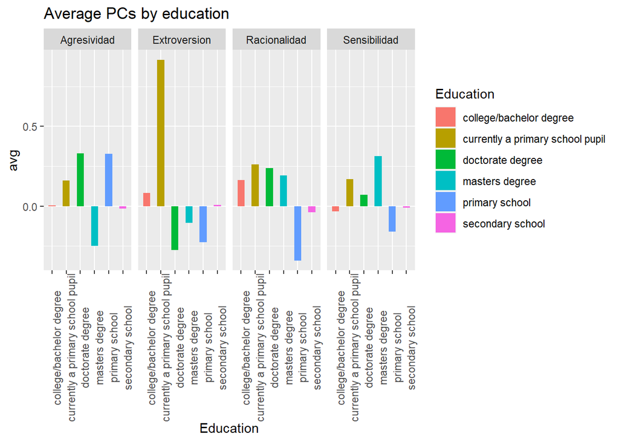

```r
pc_avgs <- data.frame(z1=x.f$scores[,1],z2=x.f$scores[,2],z3=x.f$scores[,3],z4=x.f$scores[,4], Education=data$Education) %>%
  group_by(Education) %>%
  summarise(Sensibilidad=mean(z1), Racionalidad=mean(z2), Extroversion=mean(z3), Agresividad=mean(z4))

pc_avgs <- pivot_longer(pc_avgs, cols=2:5, names_to="pc", values_to="avg")

ggplot(data=pc_avgs, aes(x=Education,y=avg,fill=Education)) +
  geom_col(width=0.5,)  +
  facet_grid(cols = vars(pc)) +
  theme(axis.text.x = element_text(angle = 90)) +labs(title="Average PCs by education")
```

## Forecasting

- Sensibilidad
- Agresividad
- Extroversión
- Racionalidad

Claramente los rasgos son opuestos dos a dos:

- Sensibilidad/agresividad
- Racionalidad/extroversión

Con esto en mente podemos elaborar una métrica con la que ubicar en un plano a las personas según su personalidad (tendríamos el eje sensibilidad/agresividad y el eje racionalidad/extroversión). Si alguien respondiese a las preguntas de la encuesta utilizando las PC o el FA podríamos tratar de predecir su personalidad. He hecho este experimento conmigo mismo:

```r
respuestas_musica = c(4,4,4,4,3,4,5,5,2,1,1,1,2,3,3,3,5,2,3)
respuestas_peliculas = c(4,3,4,4,2,3,4,3,3,4,4,5)
respuestas_hobbies = c(4,5,4,4,4,4,4,5,4,2,1,3,2,3,3,1,4,2,5,2,4,1,5,3,4,2,1,5,2,5,3,4)
respuestas_fobias = c(2,2,4,4,3,5,2,4,5,1)
respuestas_opiniones = c(4,1,3,2,3,3,4,4,2,4,5,2,2,3,1,3,5,1,4,1,2,5,4,2,1,5,2,2,4,2,4,2,4,3,3,5,3,5,3,5,3,5,1,5,1,4,4,2,4,2,5,5,1,3)
respuestas_demograficas = c(23,"Male","Right handed","College/Bachellor degree","No","Village","block of flats")
respuestas_sergio = c(respuestas_musica,
                      respuestas_peliculas,
                      respuestas_hobbies,
                      respuestas_fobias,
                      respuestas_opiniones
                      )
```

```r
length(respuestas_sergio)
```

```
## [1] 127
```

```r
dim(select(data, -demographics_column_names))
```

```
## [1] 701 127
```

```r
data_with_sergio <- rbind(select(data, -demographics_column_names), respuestas_sergio)
dim(data_with_sergio)
```

```
## [1] 702 127
```

```r
pca = prcomp(data_with_sergio, scale=T)
#calculo las pc para mis respuestas (mis respuestas están en la última fila del dataframe)
sensibilidad_sergio=pca$x[dim(data_with_sergio)[1],1]
racionalidad_sergio=pca$x[dim(data_with_sergio)[1],2]
extroversion_sergio=pca$x[dim(data_with_sergio)[1],3]
agresividad_sergio=pca$x[dim(data_with_sergio)[1],4]
```

Teniendo en cuenta que las medias de cada rasgo de la personalidad para todo el dataset tienen que ser 0 visualicemos hacia donde se desvían mis rasgos:

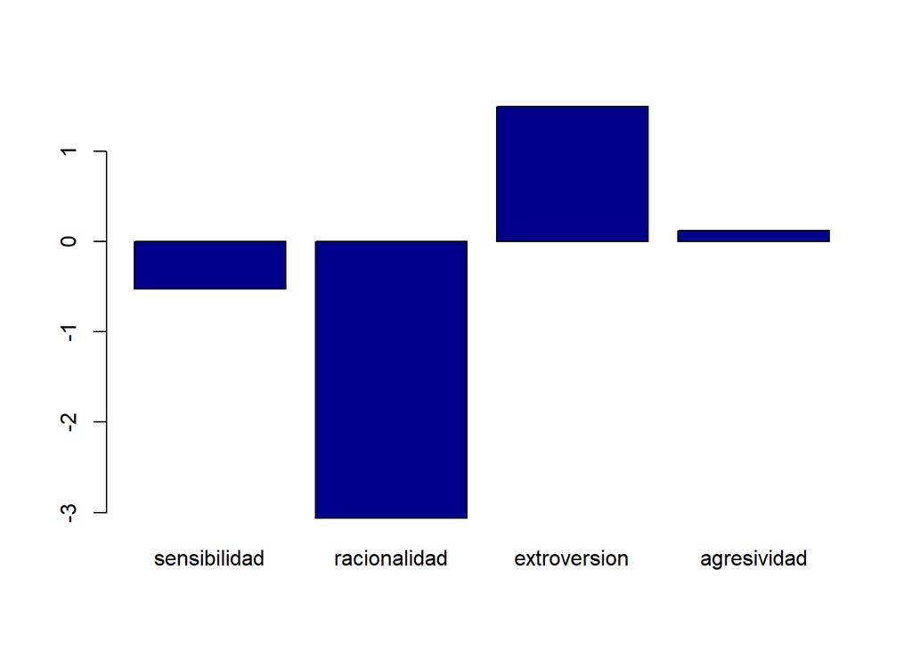

```r
rasgos_sergio = c(sensibilidad=sensibilidad_sergio,
                  racionalidad=racionalidad_sergio,
                  extroversion=extroversion_sergio,
                  agresividad=agresividad_sergio)
barplot(rasgos_sergio, col="darkblue")
```

- Sensibilidad/agresividad
- Racionalidad/extroversión

Tiene sentido (o quizás ha sido casualidad en mi caso) que las puntuaciones dos a dos de estos rasgos sea opuesta.

## Conclusiones

Remontandonos a la pregunta que nos planteábamos al principio de esta práctica:

- ¿Se puede determinar quien soy (género, edad, mano buena,…) basándonos en mis gustos, intereses, fobias y opiniones?

Estas conclusiones enumeradas han sido idénticas para PCA y factor analysis. Sabemos que la principal diferencia a nivel conceptual entre PCA y FA es que en PCA las componentes se calculan como combinaciones lineales de las variables originales y tratan de explicar tanta proporción de la varianza total de las variables como sea posible, mientras que por su parte, en FA es al revés, es decir, las variables originales se definen como combinaciones lineales de los factores que precisamente intentan explicar las covarianzas y correlaciones entre las variables.

No obstante tiene sentido y parece conclusivo en el caso de nuestro dataset que ambos métodos orientados a la reducción de dimensiones hayan ofrecido resultados prácticamente idénticos.